# **Marketing Campaign Analysis**

### **Apply DBSCAN for the best hyperparameter and visualize the clusters from PCA**

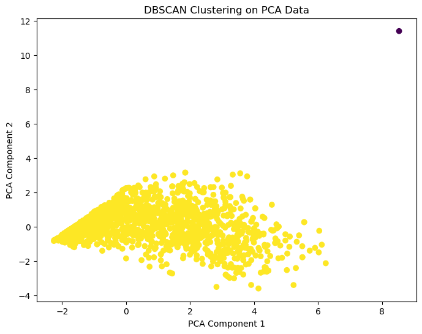

```python
# Create a DBSCAN clustering instance with specific epsilon (eps) and minimum samples (min_samples) values
dbscan = DBSCAN(eps=0.9, min_samples=2)

# Fit the DBSCAN model and get cluster labels
cluster_labels = dbscan.fit_predict(data_pca)

# Create a scatter plot to visualize the DBSCAN clustering results in the PCA space
plt.figure(figsize=(8, 6))
plt.scatter(data_pca[:, 0], data_pca[:, 1], c=cluster_labels, cmap='viridis')
plt.title("DBSCAN Clustering on PCA Data")
plt.xlabel("PCA Component 1")
plt.ylabel("PCA Component 2")

# Show the plot
plt.show()
```

**Observations and Insights:**

**Think about it:**

- Changing the eps and min sample values will result in different DBSCAN results? Can we try more value for eps and min_sample?

## **Gaussian Mixture Model**

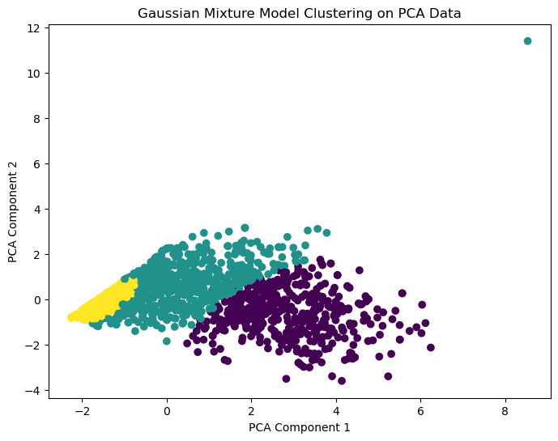

```
GMM Cluster Labels:
[0 2 1 ... 1 1 2]
```

```python
# Define the number of components for the Gaussian Mixture Model (GMM)
n_components = 3

# Create a GMM instance with the specified number of components and a random state
gmm = GaussianMixture(n_components=n_components, random_state=0)

# Fit the GMM model to the PCA-transformed data
gmm.fit(data_pca)

# Get cluster labels from the GMM model
gmm_cluster_labels = gmm.predict(data_pca)

# Create a scatter plot to visualize the GMM clustering results in the PCA space
plt.figure(figsize=(8, 6))
plt.scatter(data_pca[:, 0], data_pca[:, 1], c=gmm_cluster_labels, cmap='viridis')
plt.title("Gaussian Mixture Model Clustering on PCA Data")
plt.xlabel("PCA Component 1")
plt.ylabel("PCA Component 2")
plt.show()

# Print the GMM cluster labels
print("GMM Cluster Labels:")
print(gmm_cluster_labels)
```

**Observations and Insights:**

group one in yellow is small and mainly around PCA 1: -2 to 1 and PCA 2: -1 to 1. Group 2 is PCA 1: -2 to 4 and PCA 2: -2 to 4. group 3 is PCA 1: 0 to 6 and PCA 2: -3 to 2.

### **Visualize the clusters using PCA**

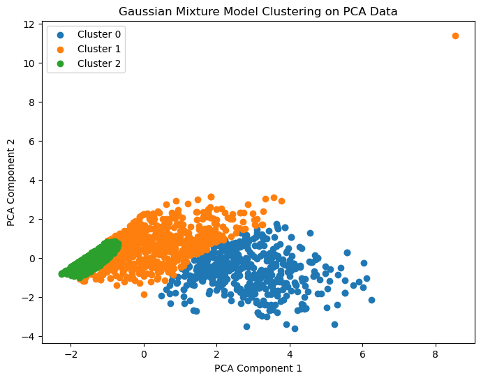

```python
# Define the number of components for the Gaussian Mixture Model (GMM)
n_components = 3

# Create a GMM instance with the specified number of components and a random state
gmm = GaussianMixture(n_components=n_components, random_state=0)

# Fit the GMM model to the PCA-transformed data
gmm.fit(data_pca)

# Get cluster labels from the GMM model
gmm_cluster_labels = gmm.predict(data_pca)

# Create a scatter plot to visualize the GMM clustering results in the PCA space
plt.figure(figsize=(8, 6))

# Loop through each cluster and plot data points with different colors for each cluster
for cluster in range(n_components):
    cluster_data = data_pca[gmm_cluster_labels == cluster]
    plt.scatter(cluster_data[:, 0], cluster_data[:, 1], label=f"Cluster {cluster}")

plt.title("Gaussian Mixture Model Clustering on PCA Data")
plt.xlabel("PCA Component 1")
plt.ylabel("PCA Component 2")
plt.legend()
plt.show()
```

### **Cluster Profiling**

```python
# Define the number of components for the Gaussian Mixture Model (GMM)
n_components = 3

# Create a GMM instance with the specified number of components and a random state
gmm = GaussianMixture(n_components=n_components, random_state=0)

# Fit the GMM model to the PCA-transformed data
gmm.fit(data_pca)

# Get cluster labels from the GMM model
gmm_cluster_labels = gmm.predict(data_pca)

# Create a copy of the original data with GMM cluster labels
data_with_clusters = data.copy()
data_with_clusters['Cluster'] = gmm_cluster_labels

# Group the data by GMM cluster labels
cluster_groups = data_with_clusters.groupby('Cluster')

# Calculate the cluster profiles (mean values of each feature for each cluster)
cluster_profiles = cluster_groups.mean()

# Get GMM cluster centers, covariances, and weights
gmm_cluster_centers = gmm.means_
gmm_cluster_covariances = gmm.covariances_
gmm_cluster_weights = gmm.weights_

# Print cluster profiles, GMM cluster centers, covariances, and weights
print("Cluster Profiles:")
print(cluster_profiles)
print("\nCluster Centers:")
print(gmm_cluster_centers)
print("\nCluster Covariances:")
print(gmm_cluster_covariances)
print("\nCluster Weights:")
print(gmm_cluster_weights)
```

```
Cluster Profiles:
          Year_Birth        Income   Kidhome  Teenhome    Recency    MntWines  \
Cluster
0        1968.507338  73264.817610  0.064990  0.289308  49.473795  542.991614
1        1966.470670  62645.365922  0.230447  0.627095  49.976257  500.005587
2        1970.538682  35541.227316  0.763133  0.522445  48.350525   60.940783

         MntFruits  MntMeatProducts  MntFishProducts  MntSweetProducts  ...  \
Cluster                                                                 ...
0        82.419287       429.970650       116.410901         85.018868  ...
1        22.424581       201.641061        32.129888         22.768156  ...
2         3.387775        23.397326         5.276027          3.595989  ...

               Age  Total_Kids  Family_Size  Total_Spending  Customer_Tenure  \
Cluster
0        47.492662    0.354298     1.354298     1338.035639       937.327044
1        49.529330    0.857542     1.857542      837.505587       928.863128
2        45.461318    1.285578     2.285578      113.744986       873.059217

         Total_Offers_Accepted  Amount_Spent_Per_Purchase  Total_Kids_Teens  \
Cluster
0                     0.494759                  65.470899          0.354298
1                     0.452514                        NaN          0.857542
2                     0.101242                        NaN          1.285578

         Total_Family_Members  Total_Amount_Spent
Cluster
0                    1.354298         1338.035639
1                    1.857542          837.505587
2                    2.285578          113.744986

[3 rows x 33 columns]

Cluster Centers:
[[ 2.71042167 -0.54584461]
 [ 0.28603966  0.59113995]
 [-1.5277201  -0.15529116]]

Cluster Covariances:
[[[ 1.53535153 -0.31631428]
  [-0.31631428  1.13131906]]

 [[ 1.32808812  0.59718544]
  [ 0.59718544  1.01073004]]

 [[ 0.09692592  0.09287889]
  [ 0.09287889  0.13310525]]]

Cluster Weights:
[0.22177428 0.32408332 0.45414241]
```

**Observations and Insights:**

Cluster 1 is closer to the origin, while Clusters 0 and 2 are farther away. This indicates the distribution of clusters in the reduced PCA space.

## **Conclusion and Recommendations**

**1. Comparison of various techniques and their relative performance based on chosen Metric (Measure of success)**:

- How do different techniques perform? Which one is performing relatively better? Is there scope to improve the performance further?

K-Means and Gaussian Mixture Models performed relatively better compared to K-Medoids and DBSCAN in creating meaningful clusters. The silhouette score was the highest for both K-Means and GMM.

**2. Refined insights**:

- What are the most meaningful insights from the data relevant to the problem?

Cluster 0, identified by K-Means, represents high-income customers who are relatively older and have accepted several marketing campaigns. They tend to purchase wine and meat products. Cluster 1, also identified by K-Means, represents lower-income customers who have accepted fewer marketing campaigns. They show lower spending across all product categories.

**3. Proposal for the final solution design:**

- What model do you propose to be adopted? Why is this the best solution to adopt?

based on the performance in clustering quality, we propose adopting K-Means for customer segmentation. K-Means creates well-separated and interpretable clusters. The K-Means results can be used for targeted marketing strategies.